# Final Project

Longhao

12/1/2018

# Abstract

This project is to use Benford’s law to examine the statistics of aviation traffic data. Every few months, department of transportation will release the data of aviation traffic, which is provided by each airline. I am interested in finding out whether the data provided by airline companies are true or not. Particularly, I selected four variables that are distinctive but also correlated with each other. They are number of available seats, number of passengers, the distance of the flight and the airtime.

## Introduction

Benford’s law is a phenomenological law also called the first digit law. This law states that in the listings, tables of statistics, etc., the digit 1 tends to occur with probability of 30%, greater than the expected of 11% (i.e., one out of nine). The mathmatical form is like below.

$$Prob(D_1=d)=log_{10}(1+\frac1d) \; for\;d =1,2,...9;$$
Here is a probability distribution table and a bar plot from 1 to 9.

| Probability | number |
| --- | --- |
| 0.3010 | 1 |
| 0.1760 | 2 |
| 0.1250 | 3 |
| 0.0970 | 4 |
| 0.0792 | 5 |
| 0.0669 | 6 |
| 0.0580 | 7 |
| 0.0512 | 8 |
| 0.0458 | 9 |

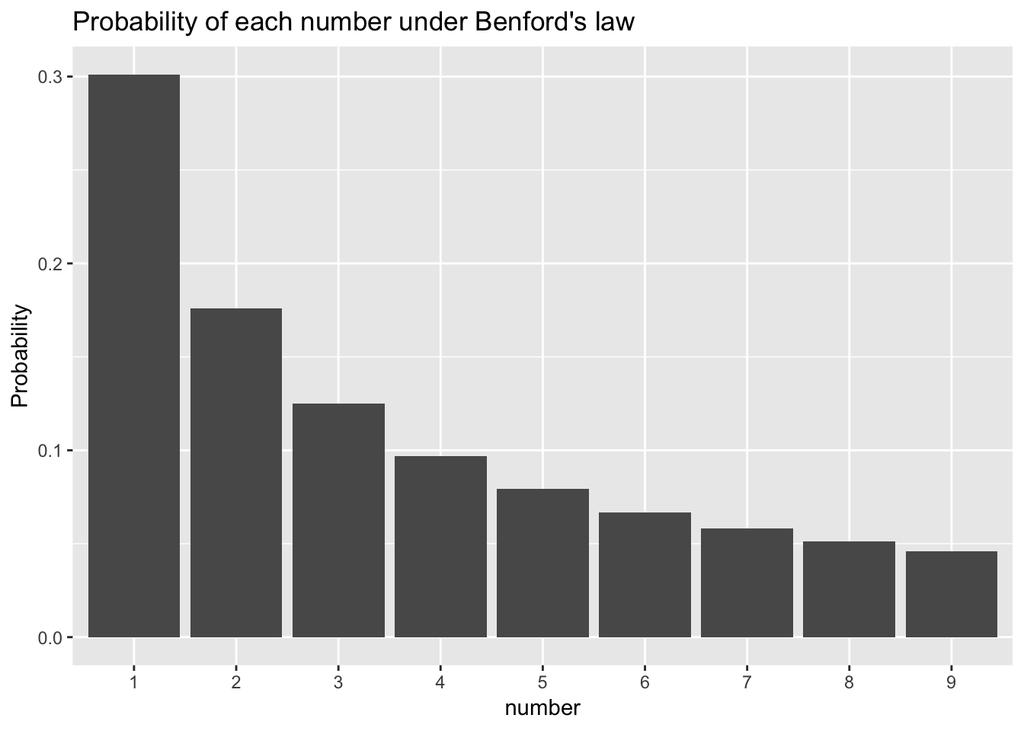

# Materials and methods

The data that constitutes this research is from Bureau of Transportation Statistics(BTS) and can be found on this website https://www.bts.gov. The job of BTS is to collect and compile the data; however, they can not guarante that the data provided by the airline companies are accurate. We will first do some visualization of our data by looking at the largest 10 airlines.

Let’s take a look at 2018 May data. We can see that out of top 10 airlines, top 3 airline companies have numbers begin with 1. Is this a conincidence or not?

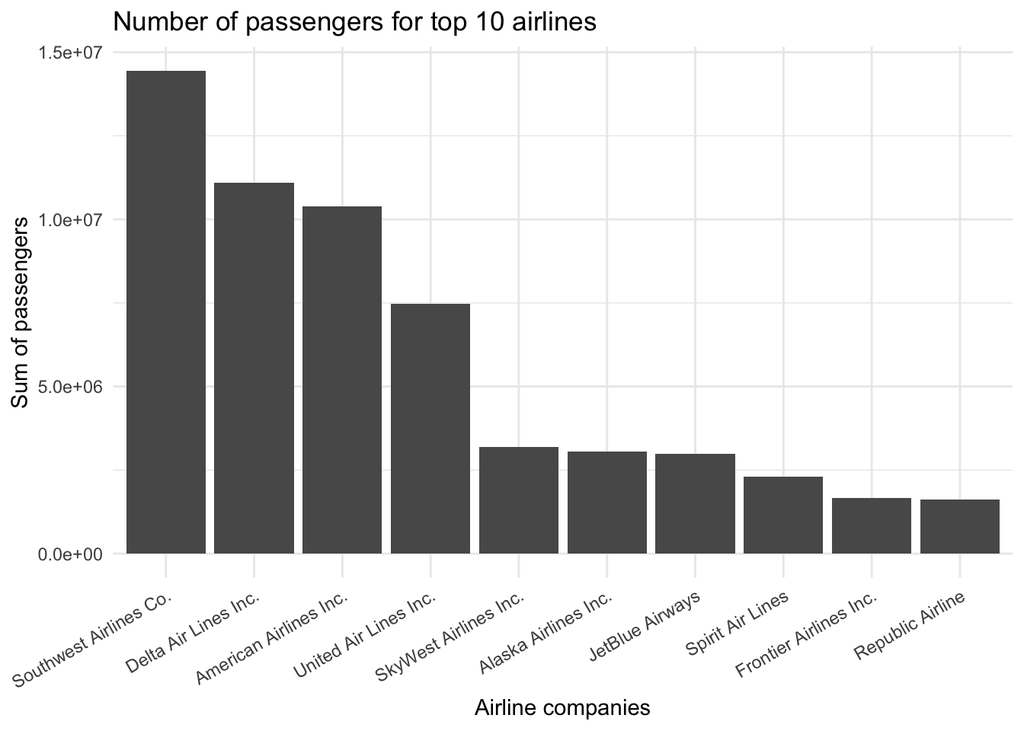

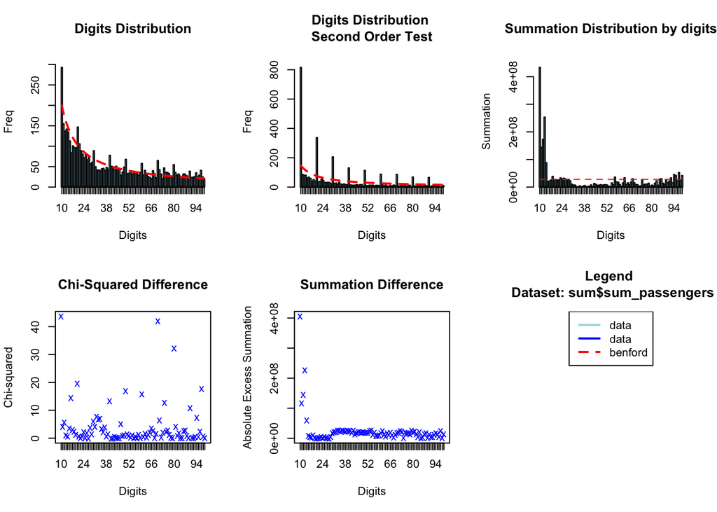

| UNIQUE_CARRIER_NAME | YEAR | MONTH | sum_seats | sum_passengers | sum_distance | sum_airtime | Date | log_passenger | log_seats | log_airtime | log_distance |
| --- | --- | --- | --- | --- | --- | --- | --- | --- | --- | --- | --- |
| 40-Mile Air | 2015 | 7 | 381 | 105 | 2712 | 8163 | 2015-07-01 | 4.663439 | 5.945421 | 9.00749 | 7.905810 |
| ACM AIR CHARTER GmbH | 2015 | 11 | 58 | 10 | 6500 | 0 | 2015-11-01 | 2.397895 | 4.077537 | 0.00000 | 8.779711 |
| Aerolitoral | 2015 | 4 | 297 | 207 | 415 | 0 | 2015-04-01 | 5.337538 | 5.697093 | 0.00000 | 6.030685 |
| Aeromexico | 2015 | 11 | 160 | 109 | 258 | 0 | 2015-11-01 | 4.700480 | 5.081404 | 0.00000 | 5.556828 |
| Air Alsie A/S | 2015 | 4 | 10 | 2 | 458 | 0 | 2015-04-01 | 1.098612 | 2.397895 | 0.00000 | 6.129050 |

| UNIQUE_CARRIER_NAME | YEAR | MONTH | sum_seats | sum_passengers | sum_distance | sum_airtime | Date |
| --- | --- | --- | --- | --- | --- | --- | --- |
| 40-Mile Air | 2015 | 7 | 381 | 105 | 2712 | 8163 | 2015-07-01 |
| ACM AIR CHARTER GmbH | 2015 | 11 | 58 | 10 | 6500 | 0 | 2015-11-01 |
| Aerolitoral | 2015 | 4 | 297 | 207 | 415 | 0 | 2015-04-01 |
| Aeromexico | 2015 | 11 | 160 | 109 | 258 | 0 | 2015-11-01 |
| Air Alsie A/S | 2015 | 4 | 10 | 2 | 458 | 0 | 2015-04-01 |

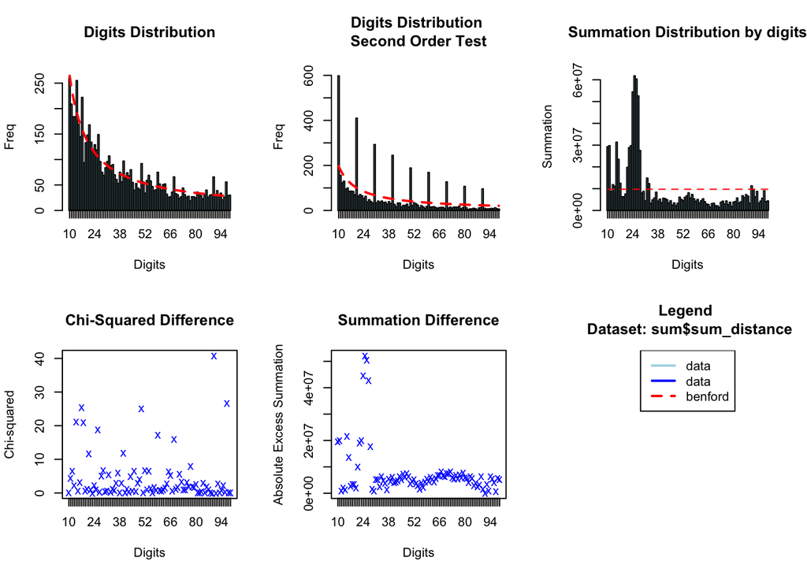

[figure not shown]